# SDM Benchmark Study Part 6: Re-Sampling Pseudo-Absence Points Using Iterative Sampling and BIOCLIM

Benton Tripp

2023-10-12

## Setup

```r
library(sf)
library(terra)
library(ggplot2)
library(ggpubr)
library(dplyr)
library(readr)
library(data.table)
library(knitr)
library(purrr)
library(caret)
library(tidyr)

# Set seed for splitting
set.seed(19)

# Load dataset containing observation points,
# but we can remove the "absence" points
df <- setDT(readRDS("artifacts/final_data/final_data.rds"))[
  observations > 0, .(common.name, state, lon, lat, geometry)]

# Define some global variables that will be referenced throughout the modeling
states <- sort(unique(df$state))
species <- sort(unique(df$common.name))
spec.state <- expand.grid(species=species,
                          state=states,
                          stringsAsFactors=F)

# Load Rasters
r.list <- states %>%
  set_names() %>%
  purrr::map(~rast(file.path("artifacts/final_rasters",
                             paste0(.x, ".tif"))))

# Pre-processed rasters
# Define min/max scaling function for rasters
min.max.scale.raster <- function(r, x=NULL, na.rm=T) {
  # If training data is provided
  if (!is.null(x)) {
    min.x <- min(x, na.rm=na.rm)
    max.x <- max(x, na.rm=na.rm)
    # Or just scale based on full raster values
  } else {
    min.x <- min(values(r), na.rm=na.rm)
    max.x <- max(values(r), na.rm=na.rm)
  }
  (r - min.x) / (max.x - min.x)
}

# Get model or other object from cache if it has been saved before
get.object <- function(obj, file.name, obj.path,
                       read.func=readRDS, save.func=saveRDS, ...) {
  f.path <- file.path(obj.path, file.name)
  if (!dir.exists(obj.path)) {
    dir.create(obj.path)
  }
  # Object cache check
  if (file.exists(f.path)) {
    obj <- read.func(f.path)
  } else {
    save.func(obj, f.path, ...)
  }
  obj
}

# Get training/testing spatstat data, and
# pre-process (scale) rasters
r.list <- states %>%
  set_names() %>%
  purrr::map(function(st) {
    get.object(obj = {
      # Get raster
      r <- r.list[[st]]
      # Compute filtered & pre-processed rasters
      names(r) %>%
        set_names() %>%
        purrr::map(function(.x) {
          cat("Pre-processing", .x, "data in", st, "\n")
          r.layer <- r[[.x]]
          if (length(unique(values(r.layer))) > 2) {
            # Scale the data
            return(min.max.scale.raster(r.layer))
          } else {
            return(r.layer)
          }
        }) %>%
        terra::rast()
    },
    file.name=paste0(st, ".tif"),
    obj.path="artifacts/preprocessed_rasters_updated",
    read.func=terra::rast,
    save.func=terra::writeRaster)
  })
```

## Updated Pseudo-Absence Selection Process

### Split into Training/Test Sets

As was done in Part 2 of the study, the data is split into a training set and a test set. The data is stratified based on latitude, longitude, species, and state to ensure that the distribution of these variables is consistent between the train and test sets. This stratification helps maintain representative samples and mitigates potential biases.

```r
stratified.split.idx <- function(df, p=0.7, lat.lon.bins=25) {
  # Cut along lat/lon values to create grids (lat.bin & lon.bin)
  # lat.lon.bins is the number of divisions you want
  df$lat.bin <- cut(df$lat, breaks=lat.lon.bins, labels = F)
  df$lon.bin <- cut(df$lon, breaks=lat.lon.bins, labels = F)

  # Create a new variable combining the stratification variables
  df %>%
    # stratify on lat/lon bins, species, state
    mutate(strata = paste(lat.bin, lon.bin, common.name, state)) %>%
    pull(strata) %>%
    # Create the data partitions
    createDataPartition(., p = p, list = F) %>%
    suppressWarnings()
}

prepare.data <- function(df, p=.7, lat.lon.bins=25) {
  train.index <- stratified.split.idx(df, p=p, lat.lon.bins = lat.lon.bins)
  df.train <- df[train.index, ]
  df.test <- df[-train.index, ]

  list(train = df.train,
       test = df.test,
       index = train.index)
}

# Get train/test indices
train.test <- prepare.data(df, .7)

# Split datatset
df.train <- df[train.test$index,]
df.test <- df[-train.test$index,]
```

### BIOCLIM

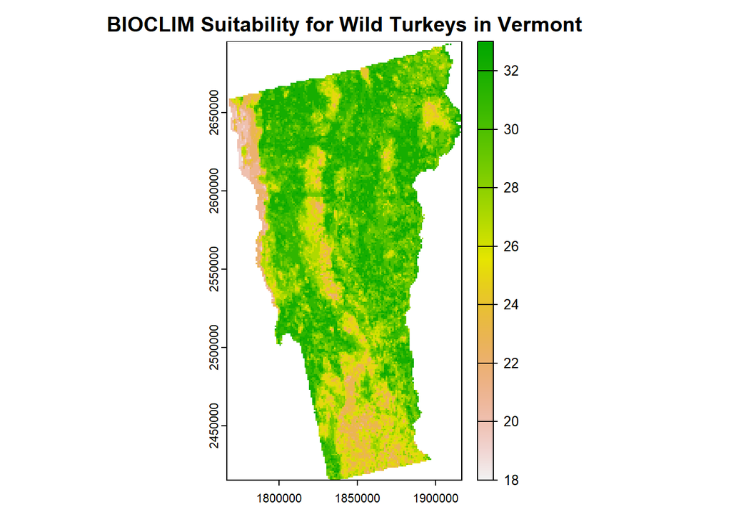

```r
bioclim.suitability <- function(sf.subset, r) {

  # Remove spatial layers (lat, lon, etc.)
  r <- r[[names(r)[!names(r) %in%
                     c("lat", "lat.sqrd", "lon",
                       "lon.lat.interaction", "lon.sqrd")]]]

  # Extract values from rasters at presence locations
  values.at.presences <- terra::extract(r, st_transform(sf.subset, crs=crs(r)))

  # Determine suitability masks based on unique values
  suitable.masks <- names(r) %>%
    set_names() %>%
    purrr::map(function(name) {
      unique.vals <- unique(values.at.presences[[name]])
      if (length(unique.vals) == 2) {
        # Binary method
        mode.val <- as.numeric(names(sort(table(values.at.presences[[name]]),
                                          decreasing = T)[1]))
        return(r[[name]] == mode.val)
      } else {
        # 10th and 90th percentile method
        lower.bound <- quantile(values.at.presences[[name]], 0.1, na.rm = T)
        upper.bound <- quantile(values.at.presences[[name]], 0.9, na.rm = T)
        return((r[[name]] >= lower.bound) & (r[[name]] <= upper.bound))
      }
    }) %>% rast()

  # Combine individual masks to get areas that have the highest suitablity
  sum(suitable.masks)
}

bcr.dir <- "artifacts/bioclim_suitable_rast"
if (!dir.exists(bcr.dir )) dir.create(bcr.dir )
bioclim.list <- purrr::map(1:nrow(spec.state), function(i) {
  st=spec.state[i,]$state
  spec=spec.state[i,]$species
  sf.subset <- sf::st_as_sf(df[state == st & common.name==spec],
                            crs=4326, sf_column_name = "geometry")
  f <- file.path(bcr.dir, paste0(st, "_", spec, ".tif"))
  if (!file.exists(f)) {
    suitable.areas <- bioclim.suitability(sf.subset, r.list[[st]])
    terra::writeRaster(suitable.areas, f)
  } else {
    suitable.areas <- rast(f)
  }
  list(
    bioclim=suitable.areas,
    state=st,
    species=spec,
    df=sf.subset
  )
})


# Example
plot(purrr::detect(bioclim.list, ~.x$state == "VT" &
             .x$species == "Wild Turkey")$bioclim,
     main = "BIOCLIM Suitability for Wild Turkeys in Vermont")
```

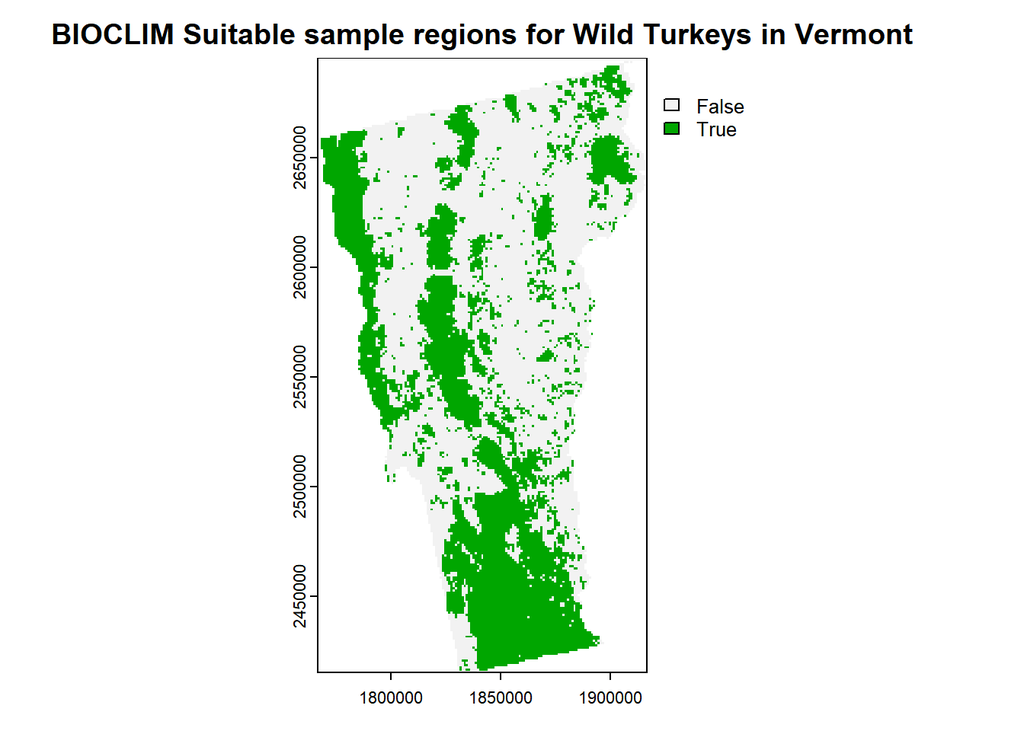

```r
# Example
qnt.5.wtvt <- quantile(values(purrr::detect(bioclim.list, ~.x$state == "VT" &
                         .x$species == "Wild Turkey")$bioclim), .5, na.rm=T)
plot(purrr::detect(bioclim.list, ~.x$state == "VT" &
             .x$species == "Wild Turkey")$bioclim < qnt.5.wtvt,
     main = "BIOCLIM Suitable sample regions for Wild Turkeys in Vermont")
```

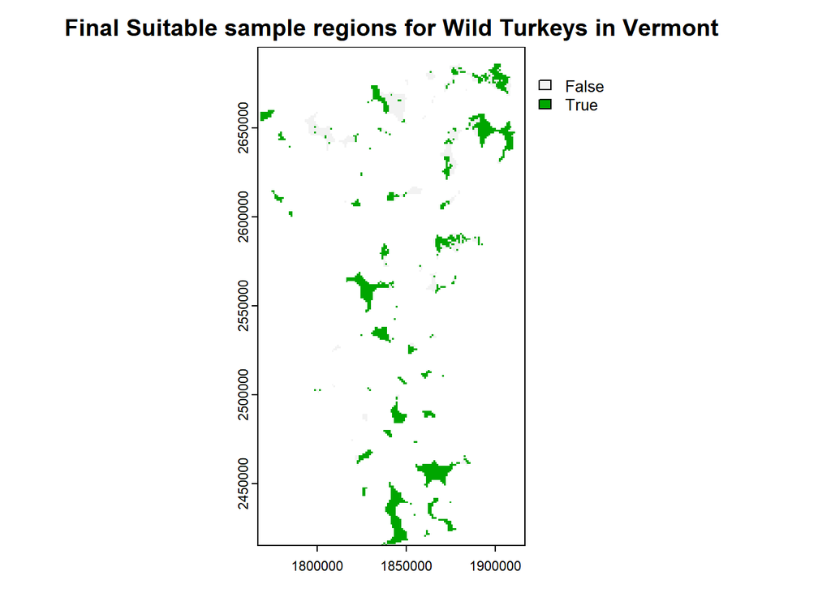

```r
# Load 5k resolution mask rasters
mask.dir <- "artifacts/masks_5k"
masks <- states %>%
  set_names() %>%
  purrr::map(function(st) {
    species %>%
      set_names() %>%
      purrr::map(function(spec) {
        fname <- file.path(mask.dir, paste0(st, "_", spec, ".tif"))
        rast(fname)
    }) %>% rast()
  })

# Load the original sample regions for pseudo-absence points
pa.regions.dir <- "artifacts/pseudo_absence_regions"
pa.regions <- states %>%
  set_names() %>%
  purrr::map(function(st) {
    species %>%
      set_names(species) %>%
      purrr::map(function(spec) {
        fname <- file.path(
          pa.regions.dir,
          gsub(" |\\-", "_", paste0(paste(st, tolower(spec), sep="_"), ".tif"))
        )
        rast(fname)
      }) %>%
      rast()
  })

purrr::walk(1:nrow(spec.state), function(i) {
  st <- spec.state[i,]$state
  spec <- spec.state[i,]$species
  msk <- masks[[st]][[spec]]
  pa.region <- pa.regions[[st]][[spec]]
  idx <- purrr::detect_index(bioclim.list, ~.x$state == st &
                        .x$species == spec)
  bioclim.list[[idx]]$mask <<- msk
  bioclim.list[[idx]]$pseudo.absence.region <<- pa.region
  qnt.5 <- quantile(values(bioclim.list[[idx]]$bioclim), .5, na.rm=T)
  bioclim.list[[idx]]$qnt.5 <<- qnt.5
  bioclim.list[[idx]]$final.pseudo.absence.region <<-
    bioclim.list[[idx]]$bioclim <= qnt.5 & pa.region == 1
})


plot(purrr::detect(bioclim.list, ~.x$state == "VT" &
             .x$species == "Wild Turkey")$final.pseudo.absence.region,
     main = "Final Suitable sample regions for Wild Turkeys in Vermont")
```

### Sampling Pseudo-Absences and Comparing Totals

This section identifies areas outside the buffers as potential zones for pseudo-absences. To ensure an accurate representation, a random sampling mechanism is implemented. For each bird species in a state, an equivalent number of pseudo-absence points (or a pre-defined minimum threshold), based on observed data are generated. The result is a set of coordinates representing regions where the bird species have not been observed.

```r
get.samples <- function(gdf, sample.idx, spec, st) {
  samples <- gdf[sample.idx,] %>%
    mutate(common.name = spec,
           state = st,
           lon = NA,
           lat = NA,
           observations=0)

  # Populate lon and lat values:
  coords <- st_coordinates(samples)
  samples$lon <- coords[, "X"]
  samples$lat <- coords[, "Y"]
  samples
}

# Function to sample n points from the non-masked parts
sample.inverse.mask <- function(r.final, n,
                                spec, st,
                                sample.crs=4326,
                                min.n=200,
                                resamples=10,
                                train.sample.size=0.7) {

  # Convert the raster to SpatialPoints
  gdf <- terra::as.points(r.final) %>%
    st_as_sf() %>%
    st_transform(crs=sample.crs)
  if (nrow(gdf) > 0) {
    gdf <- gdf %>%
      filter(!is.na(layer)) %>%
      select(geometry)
  } else {
    return(gdf)
  }

  # Set to min.n size if n < min.n
  if (n < min.n) n <- min.n
  # Last n check
  if (n > nrow(gdf)) n <- nrow(gdf)
  # Make sure there is sufficient available sample points
  resamples <- case_when(floor(nrow(gdf) / n) == 0 ~ 1,
                         floor(nrow(gdf) / n) > resamples ~ resamples,
                         T ~ floor(nrow(gdf) / n))
  cat("\tGetting", resamples, "sample(s) of", n, "for", spec, "in", st, "\n")
  if (resamples > 1) {
    sample.indices <- sample(1:nrow(gdf), n*resamples, replace = F)
    indices <- cut(sample.indices, breaks=resamples, labels = F)
  }
  # Resample multiple times
  resampled.data <- lapply(1:resamples, function(i) {
    if (resamples > 1) {
      sample.idx <- sample.indices[indices == i]
    } else {
      sample.idx <- 1:n
    }
    train.idx <- 1:floor(train.sample.size*length(sample.idx))
    test.idx <- (max(train.idx)+1):length(sample.idx)
    train.idx <- sample.idx[train.idx]
    test.idx <- sample.idx[test.idx]
    train.samples <- get.samples(gdf, train.idx, spec, st)
    test.samples <- get.samples(gdf, test.idx, spec, st)

    list(train.indices = train.idx,
         test.indices = test.idx,
         train.samples = train.samples,
         test.samples = test.samples)
  })

  # Separate the sample indices and samples into two lists
  train.indices.list <- lapply(resampled.data, `[[`, "train.indices")
  test.indices.list <- lapply(resampled.data, `[[`, "test.indices")
  train.list <- lapply(resampled.data, `[[`, "train.samples")
  test.list <- lapply(resampled.data, `[[`, "test.samples")

  list(train.indices = train.indices.list,
       test.indices = test.indices.list,
       train.samples = train.list,
       test.samples = test.list)
}

# Get totals by species and state
totals <- df[, .(.N), by=.(state, common.name)]
n.resamples <- 10
train.sample.size <- 0.7
test.sample.size <- 1 - train.sample.size

resampled.pa <- states %>%
  set_names() %>%
  purrr::map(function(st) {
    species %>%
      set_names() %>%
      purrr::map(function(spec) {
        n <- totals[state == st & common.name == spec] %>% pull(N)
        get.object({
          idx <- purrr::detect_index(bioclim.list, ~.x$state == st &
                                       .x$species == spec)
          r.final <- bioclim.list[[idx]]$final.pseudo.absence.region
          cat(idx, "- Generating ~", n, "pseudo-absence points resampled",
              n.resamples, "times for the", spec, "in", st, "\n")
          sample.inverse.mask(
            r.final, spec, st, n=n,
            sample.crs=4326,
            resamples=n.resamples,
            train.sample.size=train.sample.size)
        },
        paste0(st, "_", spec, ".rds"),
        "artifacts/resampled_pseudo_absences_with_bioclim")
      })
  })
```

```r
get.pres.df <- function(df, st, spec, r) {
  sf.pres <- sf::st_as_sf(
    df[state == st & common.name==spec,
       .(geometry, common.name, state)],
    crs=4326, sf_column_name = "geometry")
  # Extract values from rasters at presence locations
  pres.vals <- sf.pres %>%
    cbind(terra::extract(r, st_transform(sf.pres, crs=crs(r)))) %>%
    select(-ID) %>%
    st_transform(crs(sf.pres)) %>%
    filter(dplyr::if_all(names(.), ~!is.na(.))) %>%
    suppressWarnings()
}

get.abs.df <- function(df.list, r, sf.pres) {
  abs.vals <- df.list %>%
    purrr::map(~{
      .x %>%
        cbind(terra::extract(r, st_transform(.x, crs=crs(r)))) %>%
        select(-ID) %>%
        st_transform(crs(sf.pres)) %>%
        filter(dplyr::if_all(names(.), ~!is.na(.))) %>%
        suppressWarnings()
    })
}

dfs <- states %>%
  set_names() %>%
  purrr::map(function(st) {
    r <- r.list[[st]]
    species %>%
      set_names() %>%
      purrr::map(function(spec) {
        cat("Getting values for", spec, "in", st, "\n")
        get.object({
          sf.pres.train <- get.pres.df(df.train, st, spec, r)
          sf.pres.test <- get.pres.df(df.test, st, spec, r)
          abs.vals.train <- get.abs.df(resampled.pa[[st]][[spec]]$train.samples,
                                       r, sf.pres.train)
          abs.vals.test <- get.abs.df(resampled.pa[[st]][[spec]]$test.samples,
                                      r, sf.pres.test)

          list(
            presence.train=sf.pres.train,
            presence.test=sf.pres.test,
            pseudo.absence.train=abs.vals.train,
            pseudo.absence.test=abs.vals.test
          )
        },
        paste0(spec, "_", st, ".rds"),
        "artifacts/resampled_pa_with_bioclim_values")
      })
  })
```

```r
# Compare the total number of values in each dataset (just spot-checking here)
purrr::map_df(1:nrow(spec.state), function(i) {
  spec <- spec.state[i,]$species
  st <- spec.state[i,]$state
  d <- dfs[[st]][[spec]]
  prs.trn <- nrow(d$presence.train)
  prs.tst <- nrow(d$presence.test)
  p.abs.trn <- purrr::map_dbl(d$pseudo.absence.train, ~nrow(.x))
  p.abs.tst <- purrr::map_dbl(d$pseudo.absence.test, ~nrow(.x))
  tibble(
    state=st,
    species=spec,
    presence.train=prs.trn,
    presence.test=prs.tst,
    min.pseudo.abs.train=min(p.abs.trn),
    max.pseudo.abs.train=max(p.abs.trn),
    min.pseudo.abs.test=min(p.abs.tst),
    max.pseudo.abs.test=max(p.abs.tst)
  )
})
```

| state | species | presence.train | presence.test | min.pseudo.abs.train | max.pseudo.abs.train | min.pseudo.abs.test | max.pseudo.abs.test |
| --- | --- | --- | --- | --- | --- | --- | --- |
| CO | Belted Kingfisher | 3202 | 1349 | 3084 | 3288 | 1323 | 1410 |
| CO | Cedar Waxwing | 2430 | 1016 | 2356 | 2452 | 1010 | 1052 |
| CO | Downy Woodpecker | 5274 | 2237 | 5193 | 5374 | 2226 | 2304 |
| CO | Ruddy Duck | 1227 | 499 | 1157 | 1258 | 496 | 540 |
| CO | Sanderling | 101 | 30 | 121 | 153 | 53 | 66 |
| CO | Sandhill Crane | 1087 | 445 | 1047 | 1107 | 449 | 475 |
| CO | Sharp-shinned Hawk | 1599 | 658 | 1542 | 1619 | 662 | 695 |
| CO | Wild Turkey | 1845 | 766 | 1750 | 1865 | 751 | 800 |
| NC | Belted Kingfisher | 2936 | 1247 | 2884 | 2956 | 1236 | 1268 |
| NC | Cedar Waxwing | 2950 | 1245 | 2879 | 2979 | 1235 | 1277 |

[output cut: 22 more lines]

### Identify “Redundant” Rasters

As previously stated, many of the features are redundant. In particular, the “engineered” features were meant to improve upon the original features, and reduce multi-collinearity. Based on the original results of the feature selection process, it was shown that the new variables weren’t always necessarily “better”. Below is the list of raster layers that were determined should be removed from each of the rasters in order to minimize multi-collinearity and maximize model performance.

```r
# Define "redundant" rasters/features
redund.feat <- c("open_water", "developed_open_space", "developed_low_intensity",
                 "developed_medium_intensity", "developed_high_intensity", "hay_pasture",
                 "cultivated_crops", "wetlands", "forest", "lon.lat.interaction",
                 "waterbody", "urban_imperviousness", "tmax", "tmin", "dem", "Fall_NDVI",
                 "Spring_NDVI", "Summer_NDVI", "Winter_NDVI", "lat.sqrd", "lon.sqrd")
```

### Re-Fit LASSO Models with All Features

As was done in part 2, a GLM model is fit for each of the species/state subsets using the training data, but this time with the refined raster subset.

```r
# Load variable importance from fitted LASSO models
lasso.model.path="artifacts/models/lasso_3_fs"

species %>%
  purrr::walk(function(spec) {
    states %>%
      purrr::walk(function(st) {
        # Define the control for the train function
        ctrl <- trainControl(method = "cv", number = 5)

        cat("Fitting LASSO model for", spec, "in", st, "\n")
        spec.df <- dfs[[st]][[spec]]$presence.train %>%
          setDT()
        spec.df <- spec.df[
          common.name == spec & state == st][
            , `:=` (state=NULL, common.name = NULL, geometry=NULL,
                    presence=factor(T, levels=c("TRUE", "FALSE")))]

        # Remove any columns where all values are the same
        .remove <- c(names(which(sapply(spec.df, function(x) {
          length(unique(x)) <= 1}))),
          redund.feat, "lat", "lon", "observations") %>%
          unique()
        .remove <- .remove[.remove %in% names(spec.df)]
        .remove <- .remove[.remove != "presence"]
        if (!is_empty(.remove)) {
          spec.df <- spec.df %>% dplyr::select(-.remove)
        }
        train.samples <- length(dfs[[st]][[spec]]$pseudo.absence.train)
        purrr::walk(
          1:train.samples, function(i) {
            fname <- paste0(tolower(gsub(" ", "_", spec)), "_", st,
                            "_", i, "_regr_l1.rds")
            if (!file.exists(fname)) {
              if (i == 1) gc()
              cat("Fitting LASSO model for", i, "/", train.samples,
                  "iterations, for", spec, "observations in", st, "\n")
              abs.df <- dfs[[st]][[spec]]$pseudo.absence.train[[i]] %>% setDT()
              abs.df <- abs.df[
                common.name == spec & state == st][
                  , `:=` (state=NULL, common.name = NULL, geometry=NULL,
                          presence=factor(F, levels=c("TRUE", "FALSE")))]
              if (!is_empty(.remove)) {
                abs.df <- abs.df %>% dplyr::select(names(spec.df))
              }
              train.df <- data.table::rbindlist(list(spec.df, abs.df))

              # LASSO (L1); Elastic Net, where alpha = 1
              fit <- get.object(
                train(presence ~ (.)^2,
                      data = train.df,
                      method = "glmnet",
                      family = "binomial",
                      trControl = ctrl,
                      tuneGrid = expand.grid(alpha = 1,
                                             lambda = seq(0, 1, by = 0.1)),
                      metric = "Accuracy"),
                file.name=fname,
                obj.path=lasso.model.path)
              coef.df <- coef(fit$finalModel, s = fit$bestTune$lambda) %>%
                as.matrix() %>%
                as.data.frame()
              # Remove the intercept
              coef.df <- coef.df[-1, , drop = F]
              if (sum(coef.df$s1, na.rm=T) == 0) {
                # Remove file
                file.remove(file.path(lasso.model.path, fname))
                # Re-train model, this time with variable alpha in
                # the train grid
                fit <- get.object(
                  train(presence ~ (.)^2,
                        data = train.df,
                        method = "glmnet",
                        family = "binomial",
                        trControl = ctrl,
                        tuneGrid = expand.grid(
                          alpha = seq(0, 1, by = 0.1),
                          lambda = seq(0, 1, by = 0.1)),
                        metric = "Accuracy"),
                  file.name=fname,
                  obj.path=lasso.model.path)
                coef.df <- coef(fit$finalModel, s = fit$bestTune$lambda) %>%
                  as.matrix() %>%
                  as.data.frame()
                # Remove the intercept
                coef.df <- coef.df[-1, , drop = F]
                if (sum(coef.df$s1, na.rm=T) == 0) {
                  file.remove(file.path(lasso.model.path, fname))
                  cat("\tERROR: Try another method for obtaining coefs for",
                      spec, "in", st, "\n")
                }
              }
            }
          })
      })
  })
```

```
## Fitting LASSO model for Belted Kingfisher in CO
## Fitting LASSO model for 1 / 10 iterations, for Belted Kingfisher observations in CO
## Fitting LASSO model for 2 / 10 iterations, for Belted Kingfisher observations in CO
## Fitting LASSO model for 3 / 10 iterations, for Belted Kingfisher observations in CO
## Fitting LASSO model for 4 / 10 iterations, for Belted Kingfisher observations in CO
## Fitting LASSO model for 5 / 10 iterations, for Belted Kingfisher observations in CO
## Fitting LASSO model for 6 / 10 iterations, for Belted Kingfisher observations in CO
## Fitting LASSO model for 7 / 10 iterations, for Belted Kingfisher observations in CO
## Fitting LASSO model for 8 / 10 iterations, for Belted Kingfisher observations in CO
## Fitting LASSO model for 9 / 10 iterations, for Belted Kingfisher observations in CO
## Fitting LASSO model for 10 / 10 iterations, for Belted Kingfisher observations in CO
## Fitting LASSO model for Belted Kingfisher in NC
## Fitting LASSO model for 1 / 10 iterations, for Belted Kingfisher observations in NC
## Fitting LASSO model for 2 / 10 iterations, for Belted Kingfisher observations in NC
## Fitting LASSO model for 3 / 10 iterations, for Belted Kingfisher observations in NC
## Fitting LASSO model for 4 / 10 iterations, for Belted Kingfisher observations in NC
## Fitting LASSO model for 5 / 10 iterations, for Belted Kingfisher observations in NC
## Fitting LASSO model for 6 / 10 iterations, for Belted Kingfisher observations in NC
## Fitting LASSO model for 7 / 10 iterations, for Belted Kingfisher observations in NC
## Fitting LASSO model for 8 / 10 iterations, for Belted Kingfisher observations in NC
## Fitting LASSO model for 9 / 10 iterations, for Belted Kingfisher observations in NC
## Fitting LASSO model for 10 / 10 iterations, for Belted Kingfisher observations in NC
## Fitting LASSO model for Belted Kingfisher in OR
## Fitting LASSO model for 1 / 10 iterations, for Belted Kingfisher observations in OR
## Fitting LASSO model for 2 / 10 iterations, for Belted Kingfisher observations in OR
## Fitting LASSO model for 3 / 10 iterations, for Belted Kingfisher observations in OR
## Fitting LASSO model for 4 / 10 iterations, for Belted Kingfisher observations in OR
## Fitting LASSO model for 5 / 10 iterations, for Belted Kingfisher observations in OR
## Fitting LASSO model for 6 / 10 iterations, for Belted Kingfisher observations in OR
## Fitting LASSO model for 7 / 10 iterations, for Belted Kingfisher observations in OR
## Fitting LASSO model for 8 / 10 iterations, for Belted Kingfisher observations in OR
## Fitting LASSO model for 9 / 10 iterations, for Belted Kingfisher observations in OR
## Fitting LASSO model for 10 / 10 iterations, for Belted Kingfisher observations in OR
## Fitting LASSO model for Belted Kingfisher in VT
## Fitting LASSO model for 1 / 1 iterations, for Belted Kingfisher observations in VT
## Fitting LASSO model for Cedar Waxwing in CO
## Fitting LASSO model for 1 / 10 iterations, for Cedar Waxwing observations in CO
## Fitting LASSO model for 2 / 10 iterations, for Cedar Waxwing observations in CO
## Fitting LASSO model for 3 / 10 iterations, for Cedar Waxwing observations in CO
## Fitting LASSO model for 4 / 10 iterations, for Cedar Waxwing observations in CO
```

[output cut: 254 more lines]

```
## Fitting LASSO model for 9 / 10 iterations, for Wild Turkey observations in NC
## Fitting LASSO model for 10 / 10 iterations, for Wild Turkey observations in NC
## Fitting LASSO model for Wild Turkey in OR
## Fitting LASSO model for 1 / 10 iterations, for Wild Turkey observations in OR
## Fitting LASSO model for 2 / 10 iterations, for Wild Turkey observations in OR
## Fitting LASSO model for 3 / 10 iterations, for Wild Turkey observations in OR
## Fitting LASSO model for 4 / 10 iterations, for Wild Turkey observations in OR
## Fitting LASSO model for 5 / 10 iterations, for Wild Turkey observations in OR
## Fitting LASSO model for 6 / 10 iterations, for Wild Turkey observations in OR
## Fitting LASSO model for 7 / 10 iterations, for Wild Turkey observations in OR
## Fitting LASSO model for 8 / 10 iterations, for Wild Turkey observations in OR
## Fitting LASSO model for 9 / 10 iterations, for Wild Turkey observations in OR
## Fitting LASSO model for 10 / 10 iterations, for Wild Turkey observations in OR
## Fitting LASSO model for Wild Turkey in VT
## Fitting LASSO model for 1 / 1 iterations, for Wild Turkey observations in VT
```

```r
# Define min/max scaling function for rasters
min.max.scale <- function(x, na.rm=T) {
  min.x <- min(x, na.rm=na.rm)
  max.x <- max(x, na.rm=na.rm)
  (x - min.x) / (max.x - min.x)
}

get.var.imp <- function(st, spec, dir="artifacts/models/lasso_3_fs") {
  files <- list.files(dir) %>%
    .[grepl(paste(tolower(gsub(" ", "_", spec)), st, sep="_"), .)] %>%
    file.path(dir, .)
  if (length(files) == 0) return(
    tibble(
      common.name=character(0),
      state=character(0),
      variable=character(0),
      importance=numeric(0),
      wt=numeric(0),
      weighted.imp=numeric(0)
    )
  )
  var.imp <- purrr::map_df(files, ~{
    fit <- readRDS(.x)
    coef.df <- coef(fit$finalModel, s = fit$bestTune$lambda) %>%
      as.matrix() %>%
      as.data.frame()
    # Remove the intercept
    coef.df <- coef.df[-1, , drop = F]
    # Create a data frame of variable importance
    var.importance <- tibble(
      common.name = spec,
      state = st,
      variable = rownames(coef.df),
      importance = abs(coef.df[,1])
    ) %>%
      # Rank variables by importance
      arrange(state, common.name, -importance, variable) %>%
      # Only look at variables where imp. > 0
      filter(importance > 0)
  }) %>%
    mutate(n=n()) %>%
    group_by(common.name, state, variable, n, .drop=F) %>%
    summarize(importance=median(importance),
              wt=n()) %>%
    ungroup() %>%
    mutate(wt=wt/n) %>%
    select(-n) %>%
    mutate(weighted.imp=min.max.scale(wt*importance)) %>%
    arrange(-weighted.imp, variable)
}

var.imp <- purrr::map_df(1:nrow(spec.state), function(i) {
  spec <- spec.state[i,]$species
  st <- spec.state[i,]$state
  get.var.imp(st, spec)
})

var.imp
```

| common.name | state | variable | importance | wt | weighted.imp |
| --- | --- | --- | --- | --- | --- |
| Belted Kingfisher | CO | barren:developed | 3.124153e+02 | 0.0090293454 | 1.000000e+00 |
| Belted Kingfisher | CO | avg_prcp:temp.diff | 5.506706e+01 | 0.0112866817 | 2.197465e-01 |
| Belted Kingfisher | CO | developed:deciduous_forest | 5.188180e+01 | 0.0112866817 | 2.069925e-01 |
| Belted Kingfisher | CO | dem.detrended:temp.diff | 4.449509e+01 | 0.0112866817 | 1.774156e-01 |
| Belted Kingfisher | CO | developed:herbaceous | 3.902854e+01 | 0.0112866817 | 1.555271e-01 |
| Belted Kingfisher | CO | developed:emergent_herbaceous_wetlands | 3.467576e+01 | 0.0112866817 | 1.380983e-01 |
| Belted Kingfisher | CO | avg_prcp:dem.detrended | 3.016571e+01 | 0.0112866817 | 1.200398e-01 |
| Belted Kingfisher | CO | developed:shrubland | 2.396532e+01 | 0.0112866817 | 9.521299e-02 |
| Belted Kingfisher | CO | developed:evergreen_forest | 2.279763e+01 | 0.0112866817 | 9.053747e-02 |
| Belted Kingfisher | CO | avg_prcp:developed | 2.148356e+01 | 0.0112866817 | 8.527586e-02 |

[output cut: 3115 more lines]

```r
preds.abs.df <- function(df.list, tot, spec, st, files, .train=T, verbose=F) {
  preds <- purrr::map(1:tot, function(i) {
    abs.df <- df.list[[i]] %>%
      setDT() %>%
      .[common.name == spec & state == st] %>%
      .[, `:=` (state=NULL, common.name = NULL,
                geometry=geometry,
                presence=factor(F, levels=c("TRUE", "FALSE")))]
    geom <- abs.df$geometry
    abs.df[, geometry := NULL]
    if (!is_empty(.remove)) {
      abs.df <- abs.df %>% dplyr::select(-.remove)
    }
    preds.j <- files %>%
      purrr::imap(function(f, j) {
        if (verbose) cat(i, "/", tot, "Getting predictions for model", j,
                         "for", spec, "in", st, "\n")
        get.object({
          fit <- readRDS(f)
          yhat <- predict(fit, newdata=abs.df, type="prob") %>%
            setDT() %>%
            .[, .(`FALSE`)] %>%
            setnames("FALSE", paste0("abs.prob.", j))},
          paste0(st, "_", spec, "_", i, "_", j, ".rds"),
          ifelse(.train, "artifacts/pa_probs/train", "artifacts/pa_probs/test"))
      }) %>% do.call("cbind", .)

    preds.j[, `:=` (med=apply(.SD, 1, median),
                    id=.I, sample=i, train=.train,
                    geometry=geom, state=st,
                    common.name=spec)] %>%
      setorderv(x=., cols="med", order=-1)
    preds.j[, .(state, common.name, train, med, geometry)]
  }) %>% rbindlist()
}

if (!dir.exists("artifacts/pa_probs")) dir.create("artifacts/pa_probs")
get.pa.prob <- function(st, spec, dfs,
                        dir="artifacts/models/lasso_3_fs",
                        verbose=F) {
  files <- list.files(dir) %>%
    .[grepl(paste(tolower(gsub(" ", "_", spec)), st, sep="_"), .)] %>%
    file.path(dir, .)
  if (length(files) == 0) return(NULL)

  # Get columns that should be removed (based on original presence data)
  spec.df <- dfs[[st]][[spec]]$presence.train %>%
    setDT() %>%
    .[common.name == spec & state == st] %>%
    .[, `:=` (state=NULL, common.name = NULL, geometry=NULL,
              presence=factor(T, levels=c("TRUE", "FALSE")))]
  .remove <- c(names(which(sapply(spec.df, function(x) {
    length(unique(x)) <= 1}))),
    redund.feat, "lat", "lon", "observations") %>%
    unique()
  .remove <- .remove[.remove %in% names(spec.df)]
  .remove <- .remove[.remove != "presence"]
  tot.train <- length(dfs[[st]][[spec]]$pseudo.absence.train)
  tot.test <- length(dfs[[st]][[spec]]$pseudo.absence.test)
  preds.train <- preds.abs.df(dfs[[st]][[spec]]$pseudo.absence.train,
                              tot.train, spec, st, files, .train=T)
  preds.test <- preds.abs.df(dfs[[st]][[spec]]$pseudo.absence.test,
                              tot.test, spec, st, files, .train=F)
  rbindlist(list(preds.train, preds.test))
}

purrr::walk(1:nrow(spec.state), function(i) {
  spec <- spec.state[i,]$species
  st <- spec.state[i,]$state
  cat(spec, st, "\n")
  tryCatch({get.object(
    {get.pa.prob(st, spec, dfs,
                 verbose=T) %>%
        setorderv(c("train", "med"), order=c(-1, -1))},
    paste0(st, "_", spec, ".rds"),
    "artifacts/pa_prob_results"
  )}, error=function(e) NULL)
})
```

```
## Belted Kingfisher CO
## Cedar Waxwing CO
## Downy Woodpecker CO
## Ruddy Duck CO
## Sanderling CO
## Sandhill Crane CO
## Sharp-shinned Hawk CO
## Wild Turkey CO
## Belted Kingfisher NC
## Cedar Waxwing NC
## Downy Woodpecker NC
## Ruddy Duck NC
## Sanderling NC
## Sandhill Crane NC
## Sharp-shinned Hawk NC
## Wild Turkey NC
## Belted Kingfisher OR
## Cedar Waxwing OR
## Downy Woodpecker OR
## Ruddy Duck OR
## Sanderling OR
## Sandhill Crane OR
## Sharp-shinned Hawk OR
## Wild Turkey OR
## Belted Kingfisher VT
## Cedar Waxwing VT
## Downy Woodpecker VT
## Ruddy Duck VT
## Sanderling VT
## Sandhill Crane VT
## Sharp-shinned Hawk VT
## Wild Turkey VT
```

```r
purrr::walk(1:nrow(spec.state), function(i) {
  spec <- spec.state[i,]$species
  st <- spec.state[i,]$state
  f <- file.path("artifacts/pa_prob_results", paste0(st, "_", spec, ".rds"))
  if (file.exists(f)) {
    get.object({
      dt <- readRDS(f)[, .(common.name, state, train, geometry)]
      pres.train <- df.train[common.name == spec & state == st] %>%
        sf::st_as_sf(x=., crs=4326) %>%
        mutate(presence=factor(T, levels=c("TRUE", "FALSE")))
      pres.test <- df.test[common.name == spec & state == st] %>%
        sf::st_as_sf(x=., crs=4326) %>%
        mutate(presence=factor(T, levels=c("TRUE", "FALSE")))
      ntrain <- pres.train %>%
        nrow() %>%
        ifelse(. < 200, 200, .)
      ntest <- pres.test %>%
        nrow() %>%
        ifelse(. < 200, 200, .)
      cat(spec, st, ntrain, ntest, "\n")
      trn <- dt[train==T][1:ntrain] %>%
        sf::st_as_sf(x=., crs=4326) %>%
        cbind(data.frame(sf::st_coordinates(.$geometry[1:nrow(.)])) %>%
                set_names(c("lon", "lat"))) %>%
        mutate(presence=factor(F, levels=c("TRUE", "FALSE"))) %>%
        select(names(pres.train))
      trn <- do.call(what="rbind", args=list(trn, pres.train))
      tst <- dt[train==F][1:ntest] %>%
        sf::st_as_sf(x=., crs=4326) %>%
        cbind(data.frame(sf::st_coordinates(.$geometry[1:nrow(.)])) %>%
                set_names(c("lon", "lat"))) %>%
        mutate(presence=factor(F, levels=c("TRUE", "FALSE"))) %>%
        select(names(pres.test))
      tst <- do.call(what="rbind", args=list(tst, pres.test))

      list(train=trn, test=tst)
    }, paste0(st, "_", spec, ".rds"),
    "artifacts/train_test_pseudo_abs_updated")
  }
})
```

### Pre-Processing IPP Model Covariates

```r
# Ensure counter-clockwise direction
is.ccw <- function(p) {
  tryCatch({owin(poly=p); T}, error=function(e) F)
}

# Check that all polygons were traversed in the right direction
ensure.ccw <- function(polygon.list) {
  lapply(polygon.list, function(p) {
    # Check the first polygon (outer boundary)
    if (!is.ccw(p)) {
      p$x <- rev(p$x)
      p$y <- rev(p$y)
    }
    p
  })
}

# Function to convert polygon to required list format
convert.to.list.format <- function(sf.object) {
  polygons.list <- lapply(1:nrow(sf.object), function(i) {
    sfc <- st_geometry(sf.object[i,])
    if (class(sfc)[[1]] == "sfc_MULTIPOLYGON") {
      sfc <- st_cast(sfc, "POLYGON")
    }
    lapply(sfc, function(poly) {
      list(x = st_coordinates(poly)[,1],
           y = st_coordinates(poly)[,2])
    })
  })

  # If the object has only one row, we unlist one level to adhere
  # to the described format for `ppp` objects
  if (length(polygons.list) == 1) {
    polygons.list <- polygons.list[[1]]
  }

  # Ensure counter-clockwise
  polygons.list <- ensure.ccw(polygons.list)

  return(polygons.list)
}

prep.ipp.data <- function(data, st, spec,
                          r.list, just.presence=F) {
  # Filter Raster List
  r <- r.list[[st]]

  # filter by state & species
  ipp.df <- data %>%
    filter(state == st & common.name == spec) %>%
    # select location point
    select(c("lon", "lat", "presence")) %>%
    # Get the unique points, since we are not accounting
    # for the temporal nature of the data
    unique()

  # Get the first layer, set it to either NA or TRUE
  r.poly <- terra::project(x=r[[1]],
                           y=st_crs(4326, parameters=T)$Wkt) %>%
    lapp(function(z) ifelse(is.na(z), NA, T)) %>%
    terra::as.polygons() %>%
    # Convert to polygon
    st_as_sf()

  # Convert polygon to list
  r.poly.list <- convert.to.list.format(r.poly)

  # Get indices of points that are within the polygon
  valid.pts <- sapply(st_intersects(ipp.df, r.poly), function(x) length(x) > 0)

  # Filter out invalid points
  ipp.df <- filter(ipp.df, valid.pts)

  # Subset df by presence
  ipp.presence <- filter(ipp.df, presence == T)
  ipp.dummies <- filter(ipp.df, presence == F)

  # Convert the data to a ppp objects
  locations <- spatstat.geom::ppp(ipp.presence$lon,
                                  ipp.presence$lat,
                                  poly=r.poly.list)

  if (just.presence) return(locations)

  dummy.locs <- spatstat.geom::ppp(ipp.dummies$lon,
                                   ipp.dummies$lat,
                                   poly=r.poly.list)

  # Create Quadscheme
  Q <- spatstat.geom::quadscheme(locations, dummy.locs)
}

# Save training/testing spatstat data
purrr::walk(1:nrow(spec.state), function(i) {
  spec <- spec.state[i,]$species
  st <- spec.state[i,]$state
  cat("Prepping final data for", spec, "in", st, "\n")
  # Get raster
  r <- r.list[[st]]
  data <- file.path("artifacts/train_test_pseudo_abs_updated",
                    paste0(st, "_", spec, ".rds")) %>% readRDS()
  train.data <- data$train
  test.data <- data$test
  cat("\tGetting `spatstat.geom::ppp` object with training points...\n")
  Q <- get.object(
    prep.ipp.data(train.data, st, spec, r.list),
    paste0(st, "_", spec, "_Q.rds"),
    file.path("artifacts", "train_spatstat_Q_2")
  )
  cat("\tGetting `spatstat.geom::ppp` object with testing points...\n")
  Q.test <- get.object(
    prep.ipp.data(test.data, st, spec, r.list),
    paste0(st, "_", spec, "_Q.rds"),
    file.path("artifacts", "test_spatstat_Q_2")
  )
})
```